# Advanced Bioinformatics 2022 Assignment

Béibhinn O’Hora m2108139

2022-05-01

## Task 3.1

Using the sum() function and : operator, write an expression in the code snippet to evaluate the sum of all integers between 5 and 55. (5pt)

```r
## Using the sum() function, which counts the numbers within the brackets. The : operator means from:to (from a certain number to another counting all whole numbers inbetween by default)
sum(5:55)
```

```
## [1] 1530
```

## Task 3.2

Write a function called sumfun with one input parameter, called n, that calculates the sum of all integers between 5 and n. Use the function to do the calculation for n = 10, n = 20, and n = 100 and present the results. (5pt)

```r
## Defining the function sumfun to include the parameter n that will calculate sum of all intergers between 5 and n
sumfun <- function(n) {sum(5:n)}
```

```r
## When n=10
sumfun(10)
```

```
## [1] 45
```

```r
## When n=20
sumfun(20)
```

```
## [1] 200
```

```r
## When n=100
sumfun(100)
```

```
## [1] 5040
```

## Task 3.3

The famous Fibonacci series is calculated as the sum of the two preceding members of the sequence, where the first two steps in the sequence are 1, 1. Write an R script using a for loop to calculate and print out the first 12 entries of the Fibonacci series. (5pt)

```r
## Creating a function for calculating fibonnaci series of a vector with n values
fibonacci <- function(n) {
  fibonacci <-numeric(n)

## Defining fibonacci of the 1st element as 1
  fibonacci[1] <- 1

## Defining fibonacci of the 2nd element as 2
  fibonacci[2] <- 1

## Beginning the loop on the 3rd element
  i = 3

## Creating loop for the nth element of fibonacci series
  while (i <= n) {
  fibonacci[i]=fibonacci[i - 1] + fibonacci[i - 2]
  i<- i + 1
  }
## returning vector for n in fibonacci
 return(fibonacci)
}

## Entering n value of interest, which in this case is 12
fibonacci(12)
```

```
##  [1]   1   1   2   3   5   8  13  21  34  55  89 144
```

## Task 3.4

With the mtcars dataset bundled with R, use ggplot to generate a box of miles per gallon (in the variable mpg) as a function of the number of gears (in the variable gear). Use the fill aesthetic to colour bars by number of gears. (5pt)

```r
## Check that the mtcars dataset is present in R by entering mtcars, which displays contents of dataset
mtcars
```

```
##                      mpg cyl  disp  hp drat    wt  qsec vs am gear carb
## Mazda RX4           21.0   6 160.0 110 3.90 2.620 16.46  0  1    4    4
## Mazda RX4 Wag       21.0   6 160.0 110 3.90 2.875 17.02  0  1    4    4
## Datsun 710          22.8   4 108.0  93 3.85 2.320 18.61  1  1    4    1
## Hornet 4 Drive      21.4   6 258.0 110 3.08 3.215 19.44  1  0    3    1
## Hornet Sportabout   18.7   8 360.0 175 3.15 3.440 17.02  0  0    3    2
## Valiant             18.1   6 225.0 105 2.76 3.460 20.22  1  0    3    1
## Duster 360          14.3   8 360.0 245 3.21 3.570 15.84  0  0    3    4
## Merc 240D           24.4   4 146.7  62 3.69 3.190 20.00  1  0    4    2
## Merc 230            22.8   4 140.8  95 3.92 3.150 22.90  1  0    4    2
## Merc 280            19.2   6 167.6 123 3.92 3.440 18.30  1  0    4    4
## Merc 280C           17.8   6 167.6 123 3.92 3.440 18.90  1  0    4    4
## Merc 450SE          16.4   8 275.8 180 3.07 4.070 17.40  0  0    3    3
## Merc 450SL          17.3   8 275.8 180 3.07 3.730 17.60  0  0    3    3
## Merc 450SLC         15.2   8 275.8 180 3.07 3.780 18.00  0  0    3    3
## Cadillac Fleetwood  10.4   8 472.0 205 2.93 5.250 17.98  0  0    3    4
## Lincoln Continental 10.4   8 460.0 215 3.00 5.424 17.82  0  0    3    4
## Chrysler Imperial   14.7   8 440.0 230 3.23 5.345 17.42  0  0    3    4
## Fiat 128            32.4   4  78.7  66 4.08 2.200 19.47  1  1    4    1
## Honda Civic         30.4   4  75.7  52 4.93 1.615 18.52  1  1    4    2
## Toyota Corolla      33.9   4  71.1  65 4.22 1.835 19.90  1  1    4    1
## Toyota Corona       21.5   4 120.1  97 3.70 2.465 20.01  1  0    3    1
## Dodge Challenger    15.5   8 318.0 150 2.76 3.520 16.87  0  0    3    2
## AMC Javelin         15.2   8 304.0 150 3.15 3.435 17.30  0  0    3    2
## Camaro Z28          13.3   8 350.0 245 3.73 3.840 15.41  0  0    3    4
## Pontiac Firebird    19.2   8 400.0 175 3.08 3.845 17.05  0  0    3    2
## Fiat X1-9           27.3   4  79.0  66 4.08 1.935 18.90  1  1    4    1
## Porsche 914-2       26.0   4 120.3  91 4.43 2.140 16.70  0  1    5    2
## Lotus Europa        30.4   4  95.1 113 3.77 1.513 16.90  1  1    5    2
## Ford Pantera L      15.8   8 351.0 264 4.22 3.170 14.50  0  1    5    4
## Ferrari Dino        19.7   6 145.0 175 3.62 2.770 15.50  0  1    5    6
## Maserati Bora       15.0   8 301.0 335 3.54 3.570 14.60  0  1    5    8
## Volvo 142E          21.4   4 121.0 109 4.11 2.780 18.60  1  1    4    2
```

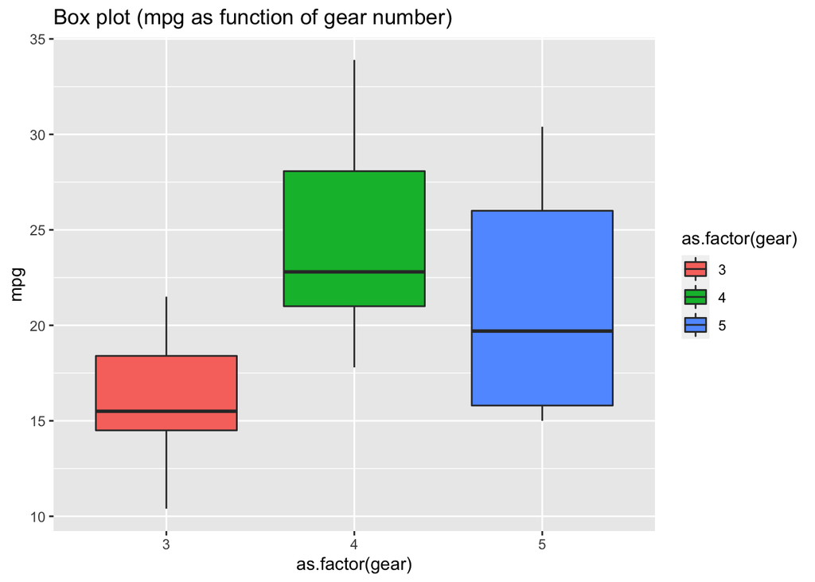

```r
## ggplot (grammar of graphics) is a logical method of building graphics from elements that sclaaes to complex figures. It combines 3 major components: data, mapping (aestetic mapping, shortened to aes in R language), and graph type (the geom to use).

## ggplot can be loaded using library(ggplot2), and can be found in packages
library(ggplot2)

## Generate a box plot of miles per gallon (in the variable mpg) as a function of the number of gears (in the variable gear).

## Use the fill aesthetic (aes) to colour bars by number of gears (3/4/5 so there should be 3 colours).

ggplot(data = mtcars, aes(x= as.factor(gear), y= mpg)) + geom_boxplot(aes(fill= as.factor(gear) )) + ggtitle("Box plot (mpg as function of gear number)")
```

## Task 3.5

Using the cars dataset and the function lm, fit a linear relationship between speed and breaking distance in the variable distance. What are the fitted slope and intercept of the line, and their standard errors? What are the units used for the variables in the dataset? (5pt)

```r
## Check that the mtcars dataset is present in R by entering mtcars, which displays contents of dataset
mtcars
```

[output not shown]

```r
## Fitting a linear relaionship between speed and breaking distance in the variable distance.
y <- cars $dist
x <- cars $speed
distance <- lm(formula = "y ~ x")

## Parameter details can be found using the summary command. For example if we are looking for parameter values of fitted model, the command summary(model) can be used. This can show residuals, coefficients, signif. codes, residual standard error, etc.
summary(distance)
```

```
##
## Call:
## lm(formula = "y ~ x")
##
## Residuals:
##     Min      1Q  Median      3Q     Max
## -29.069  -9.525  -2.272   9.215  43.201
##
## Coefficients:
##             Estimate Std. Error t value Pr(>|t|)
## (Intercept) -17.5791     6.7584  -2.601   0.0123 *
## x             3.9324     0.4155   9.464 1.49e-12 ***
## ---
## Signif. codes:  0 '***' 0.001 '**' 0.01 '*' 0.05 '.' 0.1 ' ' 1
##
## Residual standard error: 15.38 on 48 degrees of freedom
## Multiple R-squared:  0.6511, Adjusted R-squared:  0.6438
## F-statistic: 89.57 on 1 and 48 DF,  p-value: 1.49e-12
```

## Questions for task 3.5:

What are the units used for the variables in the dataset? The box plot was in miles per gallon. Thus, the variable speed would likely be in miles per hour (mph).

Based on miles being in an imperial unit, it is likely the variable distance would be in feet.

## Task 3.6. Use ggplot to plot the data points from Task 3.5 and the linear fit (5pt).

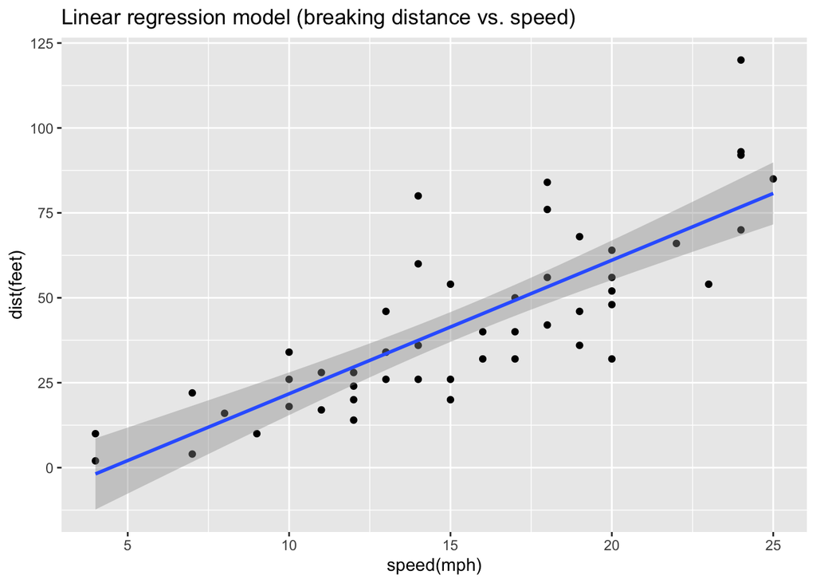

```r
## Linear regression models predict the relationship between two variables or factors. In this case it will be for breaking distance (dist) and speed

## ggplot can be loaded using library(ggplot2), and can be found in packages
library(ggplot2)

## Create the variable plot_task_3.5_data and assign the ggplot function to it.

plot_task_3.5_data_1 <- ggplot(data = cars, aes(x=speed, y=dist)) + geom_point() + geom_smooth(method = "lm", formula = "y ~ x")


## This step created the plot data. However, labels have yet to be assigned. This can be done by creating a new variable called graph_labels to add to the graph. This will then create the linear model of the relationship between speed and breaking distance.

plot_task_3.5_data_2 <- plot_task_3.5_data_1 + ggtitle ("Linear regression model (breaking distance vs. speed)")+ xlab("speed(mph)")+ ylab("dist(feet)")

## Print the linear model. Line of best fit is calculated in this model seen in the graph. This line is an output of regression analysis that predicts the relationship between the variables breaking distance (dist) and speed in a data set.
plot_task_3.5_data_2
```

```r
## To view more details about the plot
summary(plot_task_3.5_data_2)
```

```
## data: speed, dist [50x2]
## mapping:  x = ~speed, y = ~dist
## faceting: <ggproto object: Class FacetNull, Facet, gg>
##     compute_layout: function
##     draw_back: function
##     draw_front: function
##     draw_labels: function
##     draw_panels: function
##     finish_data: function
##     init_scales: function
##     map_data: function
##     params: list
##     setup_data: function
##     setup_params: function
##     shrink: TRUE
##     train_scales: function
##     vars: function
##     super:  <ggproto object: Class FacetNull, Facet, gg>
## -----------------------------------
## geom_point: na.rm = FALSE
## stat_identity: na.rm = FALSE
## position_identity
##
## geom_smooth: na.rm = FALSE, orientation = NA, se = TRUE
## stat_smooth: na.rm = FALSE, orientation = NA, se = TRUE, method = lm, formula = y ~ x
## position_identity
```

## Task 3.7.

Again using the cars dataset, now use linear regression (lm) to estimate the average reaction time for the driver to start breaking (in seconds). To simplify matters you may assume that once breaking commences, breaking distance is proportional to the square of the speed. Explain the steps in your analysis. Do you get reasonable results? Finally, use ggplot to plot the data points and the fitted relationship. (10pt)

```r
## The variable breaking_distance_ft was created to represent breaking distance in feet
breaking_distance_ft <- cars$dist

## The variable speed_mph was created to represent speed in miles per hour. It is assumed in the question that breaking distance is proportional to the square of speed. Hence, speed was squared in this variable
speed_mph <- cars$speed^2

## The linear model was created using the command: lm(formula = x ~ y), where breaking_distance_ft is x and speed_mph is y.
lm(formula = breaking_distance_ft ~ speed_mph)
```

```
##
## Call:
## lm(formula = breaking_distance_ft ~ speed_mph)
##
## Coefficients:
## (Intercept)    speed_mph
##       8.860        0.129
```

The two variables are not in the same units, one is in feet and other miles in terms of distance. To fix this breaking_distance_ft needs to be changes to breaking_distance_miles. This can be achieved by multipluing the value of one foot in miles (0.000189)

```r
## Converting feet to miles in breaking distance
breaking_distance_miles <- breaking_distance_ft* 0.000189

## print breaking_distance_miles to check it works
breaking_distance_miles
```

```
##  [1] 0.000378 0.001890 0.000756 0.004158 0.003024 0.001890 0.003402 0.004914
##  [9] 0.006426 0.003213 0.005292 0.002646 0.003780 0.004536 0.005292 0.004914
## [17] 0.006426 0.006426 0.008694 0.004914 0.006804 0.011340 0.015120 0.003780
## [25] 0.004914 0.010206 0.006048 0.007560 0.006048 0.007560 0.009450 0.007938
## [33] 0.010584 0.014364 0.015876 0.006804 0.008694 0.012852 0.006048 0.009072
## [41] 0.009828 0.010584 0.012096 0.012474 0.010206 0.013230 0.017388 0.017577
## [49] 0.022680 0.016065
```

```r
average_time_hrs <- 0.129
average_time_seconds <- 0.129/3600
average_time_seconds
```

```
## [1] 3.583333e-05
```

This can now be plotted as a linear model using the command: lm(formula = x ~ y), where breaking_distance_ft is x and speed_mph is y,

[figure not shown]

```r
## Linear regression models predict the relationship between two variables or factors. In this case it will be for breaking distance in miles and speed in seconds

## ggplot can be loaded using library(ggplot2), and can be found in packages
library(ggplot2)

## Create the variable plot_task_3.7_data and assign the ggplot function to it.

plot_task_3.7_data_1 <- ggplot(data = cars, aes(x=average_time_seconds, y=breaking_distance_miles)) + geom_point() + geom_smooth(method = "lm", formula = "y ~ x")

## This step created the plot data. However, labels have yet to be assigned. This can be done by creating a new variable called graph_labels to add to the graph. This will then create the linear model of the relationship between speed and breaking distance.

plot_task_3.7_data_2 <- plot_task_3.5_data_1 + ggtitle ("Linear regression model (breakingdistance (miles) vs. speed (seconds))")+ xlab("speed(seconds)")+ ylab("dist(miles)")

## Print the linear model. Line of best fit is calculated in this model seen in the graph. This line is an output of regression analysis that predicts the relationship between the variables breaking distance (dist) and speed in a data set.
plot_task_3.7_data_2
```

```r
## To view more details about the plot
summary(plot_task_3.5_data_2)
```

```
## data: speed, dist [50x2]
## mapping:  x = ~speed, y = ~dist
## faceting: <ggproto object: Class FacetNull, Facet, gg>
##     compute_layout: function
##     draw_back: function
##     draw_front: function
##     draw_labels: function
##     draw_panels: function
##     finish_data: function
##     init_scales: function
##     map_data: function
##     params: list
##     setup_data: function
##     setup_params: function
##     shrink: TRUE
##     train_scales: function
##     vars: function
##     super:  <ggproto object: Class FacetNull, Facet, gg>
## -----------------------------------
## geom_point: na.rm = FALSE
## stat_identity: na.rm = FALSE
## position_identity
##
## geom_smooth: na.rm = FALSE, orientation = NA, se = TRUE
## stat_smooth: na.rm = FALSE, orientation = NA, se = TRUE, method = lm, formula = y ~ x
## position_identity
```

```r
## To find correlation between two variables dist and speed.
cor(cars$speed, cars$dist)
```

```
## [1] 0.8068949
```

There is a high positive correlation between speed and dist.